# Markdown Project!

Jahnavi Kodavanti

13/08/2020

```r
library(knitr)
library(ggplot2)
library(data.table)
knitr::opts_chunk$set(echo = TRUE,results = 'hold')
```

**Loading data**

```r
activity <- unzip("repdata_data_activity.zip")
a_data <- read.csv("activity.csv", header=TRUE, sep=",")
a_data$date <- as.Date(a_data$date, format="%Y-%m-%d")
a_data$interval <- as.factor(a_data$interval)
str(a_data)
```

```
## 'data.frame':    17568 obs. of  3 variables:
##  $ steps   : int  NA NA NA NA NA NA NA NA NA NA ...
##  $ date    : Date, format: "2012-10-01" "2012-10-01" ...
##  $ interval: Factor w/ 288 levels "0","5","10","15",..: 1 2 3 4 5 6 7 8 9 10 ...
```

**mean total number of steps taken per day:-**

1.calculating the total number of steps taken per day:

```r
steps_day<-aggregate(steps ~ date, data=a_data, FUN=sum)
head(steps_day)
```

```
##         date steps
## 1 2012-10-02   126
## 2 2012-10-03 11352
## 3 2012-10-04 12116
## 4 2012-10-05 13294
## 5 2012-10-06 15420
## 6 2012-10-07 11015
```

2.histogram of the total number of steps taken each day

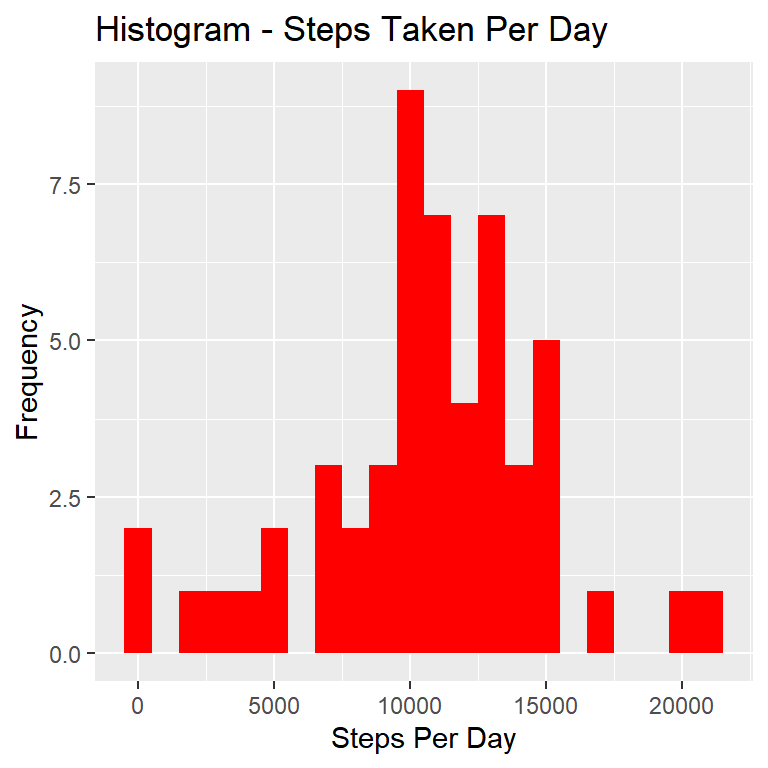

```r
ggplot(steps_day, aes(x = steps)) +
  geom_histogram(fill="red",binwidth = 1000) +
  labs(title = "Histogram - Steps Taken Per Day", x = "Steps Per Day", y = "Frequency")
```

3.Mean and Median of the total number of steps taken per day

```r
mean_steps_day<- mean(steps_day$steps)
print(mean_steps_day)
median_steps_day <- median(steps_day$steps)
print(median_steps_day)
```

```
## [1] 10766.19
## [1] 10765
```

**average daily activity pattern:-**

1.time series plot:

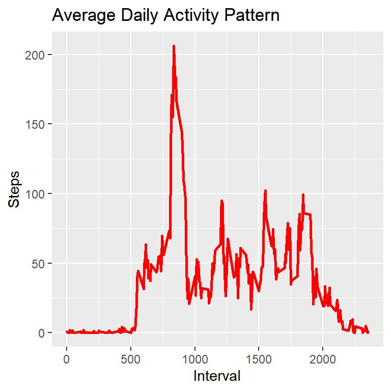

```r
steps_interval <- aggregate(steps ~ interval, data = a_data,
                            FUN = mean, na.rm = TRUE)
steps_interval$interval<- as.integer(levels(steps_interval$interval)[steps_interval$interval])
ggplot(steps_interval, aes(x = interval, y = steps)) +
  geom_line(col = "red", size = 1) +
  labs(title = "Average Daily Activity Pattern", x = "Interval", y = "Steps")
```

2. maximum number of steps:

```r
max_interval <- steps_interval[which.max(steps_interval$steps),]
print(max_interval)
```

```
##     interval    steps
## 104      835 206.1698
```

**Imputing missing values:-**

1.total number of missing values in the dataset:

```r
missing_values <- sum(is.na(a_data$steps))
missing_values
```

```
## [1] 2304
```

2.We can replace missing values with their mean values.

3.new dataset that is equal to the original dataset but with the missing data filled in:

```r
new_a_data <- a_data
index_of_na <- which(is.na(new_a_data$steps))
for (i in index_of_na)
  {
  new_a_data$steps[i] <- with(steps_interval,
                              steps[interval =new_a_data$interval[i]])
  }
head(new_a_data)
```

```
##       steps       date interval
## 1 1.7169811 2012-10-01        0
## 2 0.3396226 2012-10-01        5
## 3 0.1320755 2012-10-01       10
## 4 0.1509434 2012-10-01       15
## 5 0.0754717 2012-10-01       20
## 6 2.0943396 2012-10-01       25
```

4.Impact of imputing missing data on the estimates of the total daily number of steps:

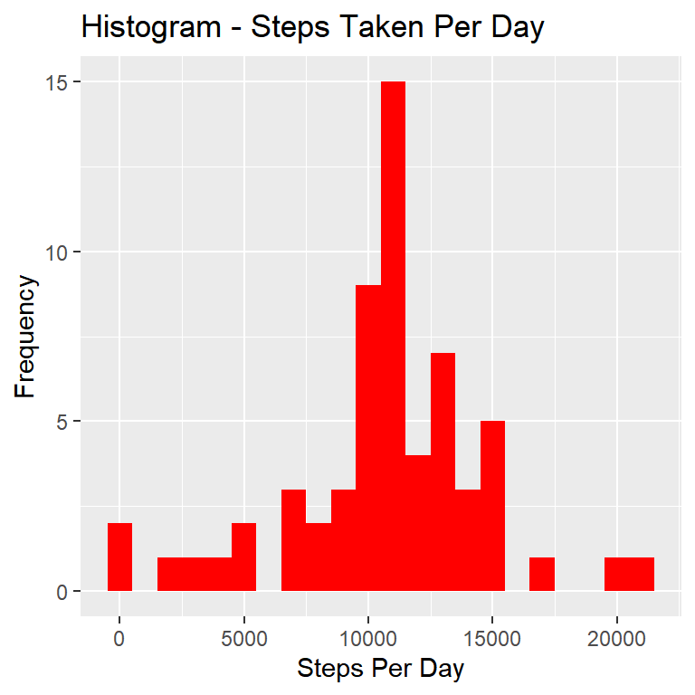

```r
new_steps_day <- aggregate(steps ~ date, data = new_a_data, FUN=sum)
ggplot(new_steps_day, aes(x = steps)) +
  geom_histogram(fill = "red", binwidth = 1000) +
  labs(title = "Histogram - Steps Taken Per Day", x = "Steps Per Day",
       y = "Frequency")
```

```r
new_mean_steps_day <- mean(new_steps_day$steps)
new_mean_steps_day
new_median_steps_day <- median(new_steps_day$steps)
new_median_steps_day
```

```
## [1] 10766.19
## [1] 10766.19
```

*Both mean and median of steps taken per day are exactly same which was not the case prior to imputing missing values*

**differences in activity patterns between weekdays and weekends:-**

1.Indicating whether a given date is a weekday or weekend day:

```r
data1 <- data.table(new_a_data)
data1[, weekday := ifelse(weekdays(date) %in% c("Saturday", "Sunday"), "Weekend", "Weekday")]
data1$weekday <- as.factor(data1$weekday)
data1$interval <- as.integer(levels(data1$interval)[data1$interval])
head(data1,8)
```

```
##        steps       date interval weekday
## 1: 1.7169811 2012-10-01        0 Weekday
## 2: 0.3396226 2012-10-01        5 Weekday
## 3: 0.1320755 2012-10-01       10 Weekday
## 4: 0.1509434 2012-10-01       15 Weekday
## 5: 0.0754717 2012-10-01       20 Weekday
## 6: 2.0943396 2012-10-01       25 Weekday
## 7: 0.5283019 2012-10-01       30 Weekday
## 8: 0.8679245 2012-10-01       35 Weekday
```

2.Panel plot containing a time series plot:

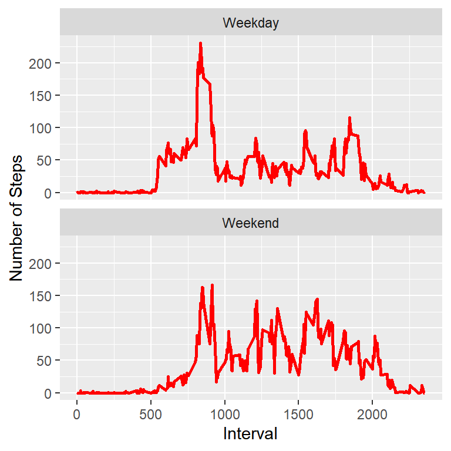

```r
steps_weekday <- aggregate(steps ~ interval+weekday, data = data1,
                           FUN = mean)
ggplot(steps_weekday, aes(x = interval, y = steps)) +
  geom_line(col = "red", size = 1) +
  facet_wrap(~ weekday, nrow=2, ncol=1) +
  labs(x = "Interval", y = "Number of Steps")
```

**Conclusion**

*activity on weekdays has the highest peak compared to all intervals.* weekend intervals have more peaks than weekday.